# 03_D_TSGraphs_MoreExercises

```r
library(readr)
library(readxl)
library(fpp3)
```

# 1 Beijing pollution

The code below imports measurements from a station located in Beijing that measures NO2, CO and SO2 levels, as well as other basic weather-related variables. Run the code and a pop-up window will request you to select a file. Select the file `Beijing_Pollution_TSeries.csv`, which you must download from the ZZ_Datasets folder located in google drive:

```r
pollution <-

  # Read the file
  read_csv(file.choose()) %>%

  #Step 1: create the time_stamp
  mutate(time_stamp = make_datetime(year, month, day, hour)) %>%

  #Step 2: reorder columns and drop timestamp components (keep only the newly created     timestamp)
  select(time_stamp, everything(), -c(No, year, month, day, hour))  %>%

  #Step 3: convert to tsibble
  as_tsibble(index = time_stamp)

pollution
```

The code below performs a quick graph of the measurements of NO2 levels contained in the dataset:

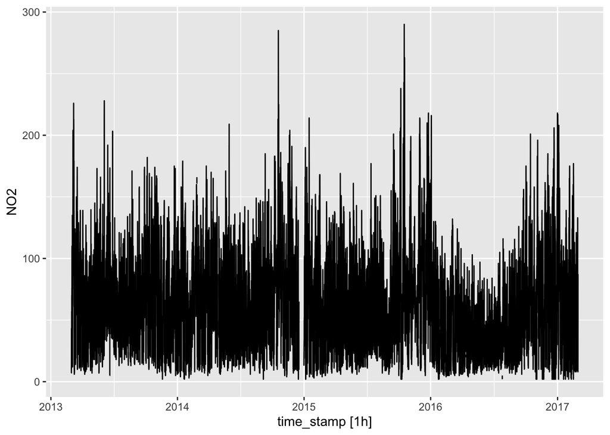

```r
autoplot(pollution, NO2)
```

## 1.1 Average weekly values

Use `index_by()` to define a new tsibble `NO2_weekly` that processes the hourly values contained in the tsibble `pollution` and computes average weekly values of NO2 levels. For details on how to use `index_by()` refer to the notebook on tsibbles that we saw in class and you can find in google drive.

Afterwards create a new column on `NO2_weekly` that contains the combination of year and month corresponding to each row.

Following this filter the dataset to contain only values between March 2013 (included) and March 2014 (excluded).

## 1.2 Timeplot using weekly data

Create a timeplot using `NO2_weekly`. The timeplot must have major break every month. Desired output below:

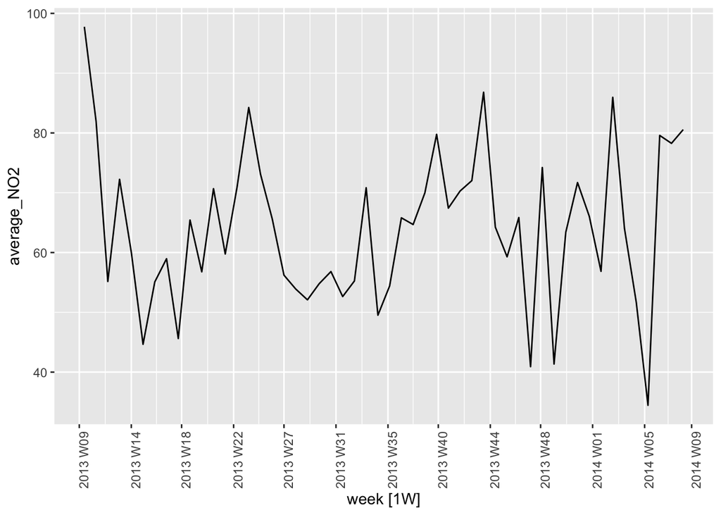

## 1.3 repeat the tasks detailed in 1.1 and 1.2, but this time the aggregation must compute monthly values and store them in `NO2_monthly`. Then create a plot that depicts that data and has ticks every month:

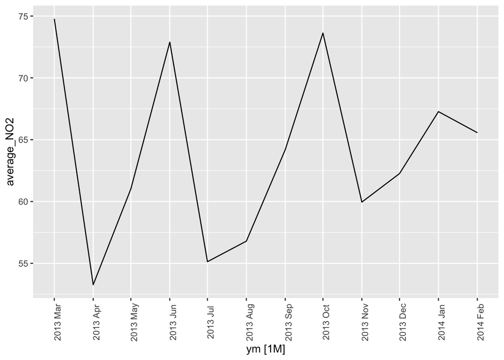

# 2. Fuel Prices

The code below performs the necessary transformations to turn the data contained in the file `Weekly Fuel Prices.xlsx` into a tsibbl. You will find this data in the google drive folder, under `ZZ_Datasets`. Run the code and a pop-up window will request you to select a file. Select `Weekly Fuel Prices.xlsx`, which you must previously download to your computer:

```r
fuel_prices <-

  # Read excel file
  read_xlsx(file.choose(),
            col_types = c ("date", "numeric", "numeric")) %>%

  filter(!is.na(Date)) %>%

  pivot_longer(cols = c("Petrol (USD)", "Diesel (USD)"),
               names_to = "fuel_type",
               values_to = "price_USD"
               ) %>%

  as_tsibble(key =  fuel_type, regular = FALSE, index = Date)

fuel_prices
```

## 2.1 Quarterly aggregation with index_by

The code below is used to produce the average quarterly prices, separating by fuel_type.

Experiment with excluding vs including the command `group_by(fuel_type)` before `index_by(yq = yearquarter(Date))`. How does the result change?

For the next section, include the `group_by` and store the result in fuel_quarterly.

```r
fuel_quarterly <-

  fuel_prices %>%

  # Use group_by so that the subsequeny index_by is applied
  # group-wise.
  group_by(fuel_type) %>%

  # Index by yearquarter
  index_by(yq = yearquarter(Date)) %>%

  # Summarise
  summarise(
      petrol_mean_USD = mean(price_USD, na.rm = TRUE)
  ) %>%

  ungroup()
```

## 2.2 Time-plot

Filter the object fuel_quarterly to contain only information between 2004 and 2008 (both included).

Then produce the graph below. Ensure that you have major ticks every year and minor ticks every quarter.

HINT: for the minor ticks you may need to generate a sequence of yearquarter objects, as explained in the notebook covering dates and times in R.

```
Plot variable not specified, automatically selected `.vars = petrol_mean_USD`
```

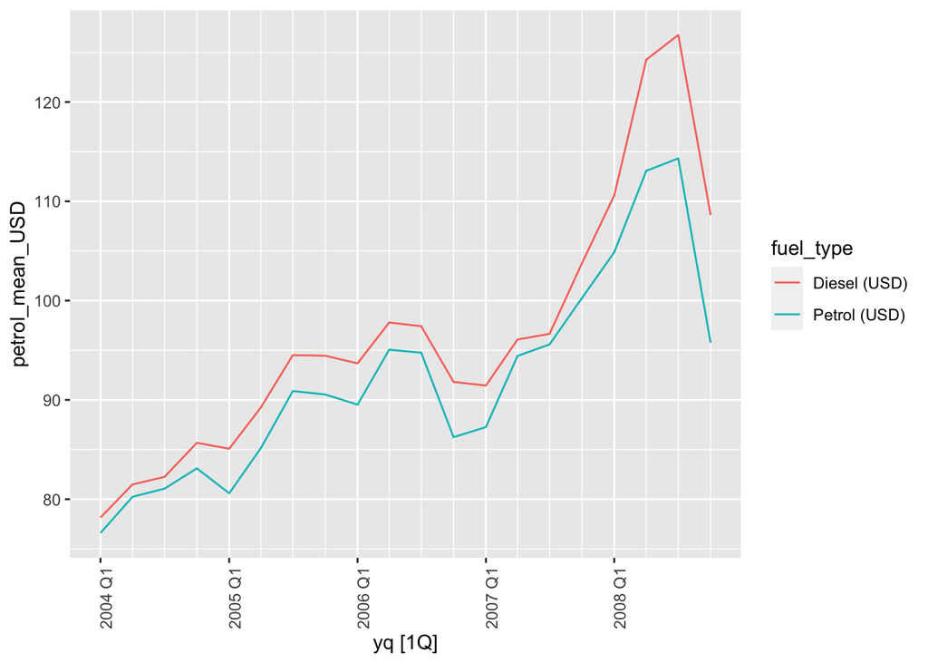